# REM Sleep Analysis

Devon Mastin

2023-09-14

## Introduction

This page will run some simple analyses a data set included in ggplot2 called msleep.

## Long Data Frame

| Common Name | Total Sleep (h) |
| --- | --- |
| Cheetah | 12.1 |
| Owl monkey | 17.0 |
| Mountain beaver | 14.4 |
| Greater short-tailed shrew | 14.9 |
| Cow | 4.0 |
| Three-toed sloth | 14.4 |
| Northern fur seal | 8.7 |
| Vesper mouse | 7.0 |
| Dog | 10.1 |
| Roe deer | 3.0 |
| Goat | 5.3 |
| Guinea pig | 9.4 |
| Grivet | 10.0 |
| Chinchilla | 12.5 |
| Star-nosed mole | 10.3 |
| African giant pouched rat | 8.3 |
| Lesser short-tailed shrew | 9.1 |
| Long-nosed armadillo | 17.4 |
| Tree hyrax | 5.3 |
| North American Opossum | 18.0 |
| Asian elephant | 3.9 |
| Big brown bat | 19.7 |
| Horse | 2.9 |
| Donkey | 3.1 |
| European hedgehog | 10.1 |
| Patas monkey | 10.9 |
| Western american chipmunk | 14.9 |
| Domestic cat | 12.5 |
| Galago | 9.8 |
| Giraffe | 1.9 |

[output cut: 53 more lines]

This is a long data frame with many many rows. Nobody wants to look at this. Lets see if we can get a better look.

## Visualization

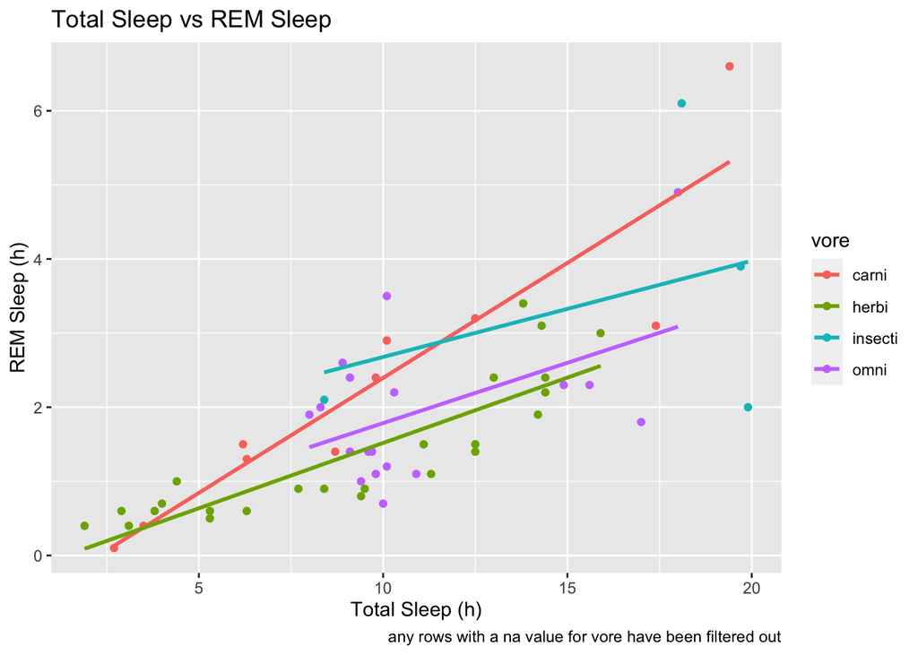

Cool! Lets look at another relationship…

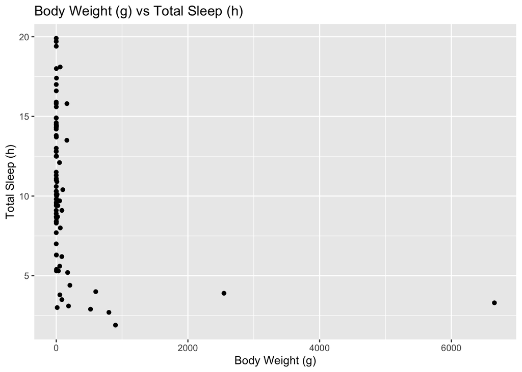

It doesn’t look like there is much of a relationship here but let’s filter out those larger values to get a better picture.

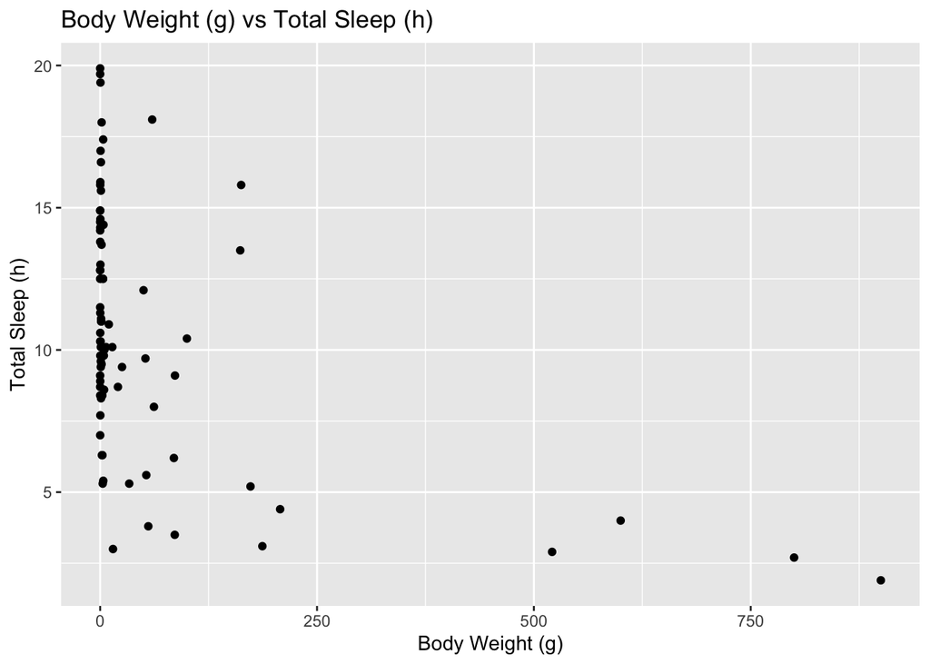

Maybe, but not really clear. Lets run a statistical analysis on the data (bringing back in those values that we filtered out).

```
## [1] "pearson correlation coefficient: -0.312010598447784"
```

Ok, so our correlation between those two variables is pretty weak, which makes sense when we look at our graph. Let’s look for a strong correlation somewhere else.

## Correlation Matrix

I am using a cool package called ggcorrplot which lets me make a visual correlation matrix, though when I tried this with all the data it was a huge mess. So I selected all the numeric data and ran the matrix.

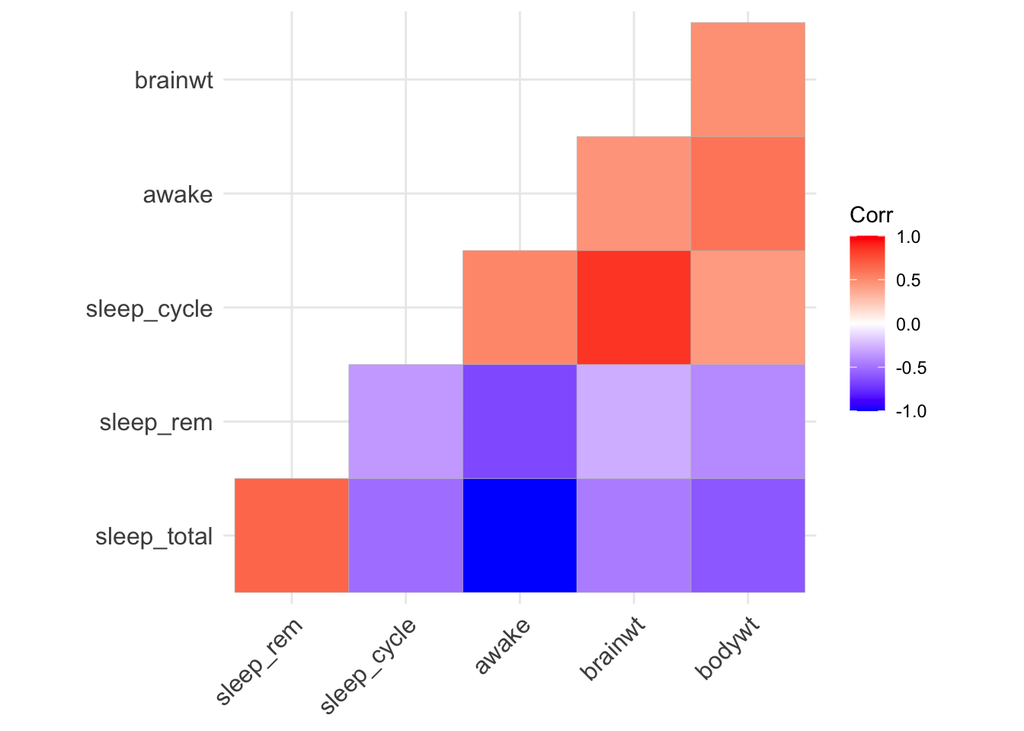

It shows an interesting relationship I wouldn’t have thought to check for between sleep cycle time and brain weight. Lets look a little closer at this.

## Brain Weight and Sleep Cycle Time

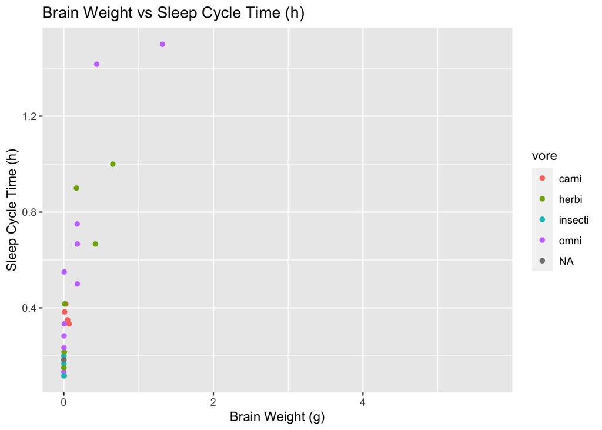

```
## [1] "correlation_coefficient: 0.851620348196375"
```

```
## [1] "P-value: 2.42032871523376e-09"
```

## Order and Sleep

Let’s look at whether the order affects the total sleep time and REM sleep. There are a lot of orders so I am just going to look at Rodentia and Carnivora.

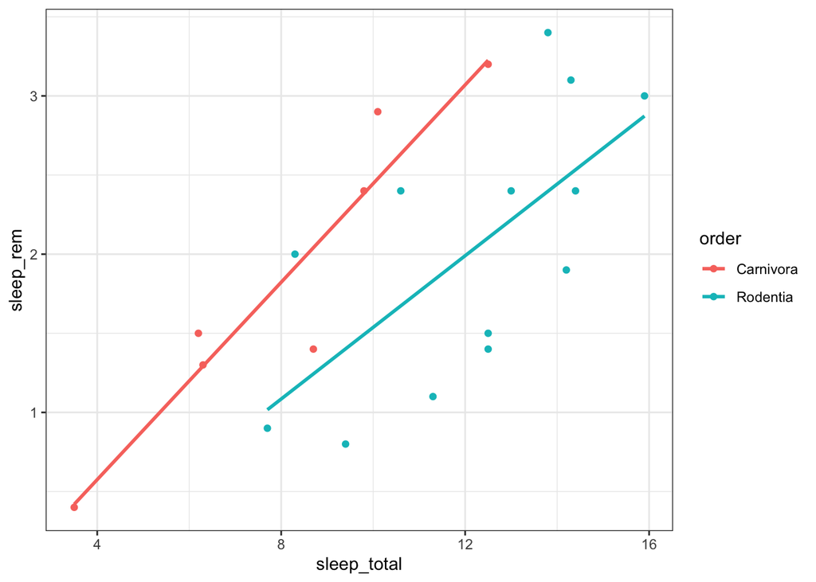

Let’s run a linear model to ask that question from above; is the effect of total sleep on REM sleep different for the orders Rodentia and Carnivora?

```r
model1<-lm(sleep_rem~sleep_total*order, data=sleep)
summary(model1)
```

```
##
## Call:
## lm(formula = sleep_rem ~ sleep_total * order, data = sleep)
##
## Residuals:
##      Min       1Q   Median       3Q      Max
## -0.73157 -0.59132 -0.00597  0.28477  1.00262
##
## Coefficients:
##                           Estimate Std. Error t value Pr(>|t|)
## (Intercept)               -0.67168    0.67971  -0.988  0.33777
## sleep_total                0.31176    0.07883   3.955  0.00114 **
## orderRodentia             -0.05421    1.06706  -0.051  0.96011
## sleep_total:orderRodentia -0.08544    0.10307  -0.829  0.41934
## ---
## Signif. codes:  0 '***' 0.001 '**' 0.01 '*' 0.05 '.' 0.1 ' ' 1
##
## Residual standard error: 0.5825 on 16 degrees of freedom
## Multiple R-squared:  0.6327, Adjusted R-squared:  0.5639
## F-statistic: 9.188 on 3 and 16 DF,  p-value: 0.0009067
```

We looked at whether total sleep, order, or the interaction between the two variables had a determining factor on how much REM sleep the animal got. When we look at our p-values it looks like total sleep did have a significant effect (shocker!), but order, and the combined effect of order and total sleep were not significant factors.

Let’s a new data set where REM sleep is a function of total sleep or order, but total sleep and order are not dependent on eachother, then model it.

```r
model2 <- lm(sleep_rem~sleep_total+order, data=sleep)
summary(model2)
```

```
##
## Call:
## lm(formula = sleep_rem ~ sleep_total + order, data = sleep)
##
## Residuals:
##      Min       1Q   Median       3Q      Max
## -0.71571 -0.53152  0.01754  0.27203  0.98379
##
## Coefficients:
##               Estimate Std. Error t value Pr(>|t|)
## (Intercept)   -0.26398    0.46481  -0.568   0.5775
## sleep_total    0.26178    0.05032   5.203 7.19e-05 ***
## orderRodentia -0.89261    0.33688  -2.650   0.0169 *
## ---
## Signif. codes:  0 '***' 0.001 '**' 0.01 '*' 0.05 '.' 0.1 ' ' 1
##
## Residual standard error: 0.5771 on 17 degrees of freedom
## Multiple R-squared:  0.617,  Adjusted R-squared:  0.5719
## F-statistic: 13.69 on 2 and 17 DF,  p-value: 0.0002868
```

Now let’s look at whether the two models are significantly different from each other.

```
## Analysis of Variance Table
##
## Model 1: sleep_rem ~ sleep_total * order
## Model 2: sleep_rem ~ sleep_total + order
##   Res.Df    RSS Df Sum of Sq      F Pr(>F)
## 1     16 5.4290
## 2     17 5.6621 -1  -0.23314 0.6871 0.4193
```

The two models are not significantly different from each other as evidenced by our high p-value, and with our first model we lose a degree of freedom, so the second model may be a better option.

We want to add in a column that shows a predicted lm value based on the second model then visualize it.

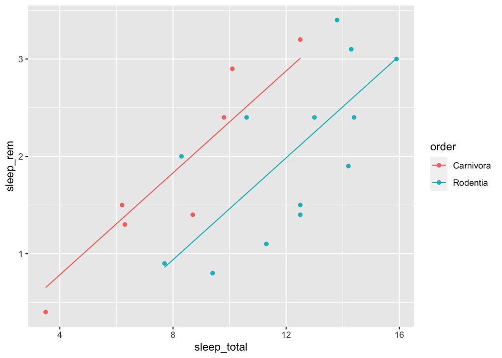

```r
sleep$predlm<-predict(model2)
ggplot(sleep, aes(x=sleep_total, y=sleep_rem, colour=order))+
  geom_point()+
  geom_line(aes(y=predlm))
```